# Text mining prediction EPMC: Technical report

### Synopsis

We collaborated the EPMC team at EBI to use text-mining techniques that use a set of keywords (see Appendix) that describe potential interaction relationships to identify sentences that may depict interacting proteins. The sentences are extracted from the abstract or full text (when available, due to copyright restrictions) or publications listed in PubMed. The text-mining exercise was performed by Senay Kafkas (SK). Email exchange about this subject can be found in the folder ./source_files/emails.

### Part 1: Evaluate and extract information from SK file

SK sent the result file from her search script on 2015/08/28 and an updated version with all PMIDs added on 2016/04/07. Here is the text of the email she sent on the first instance:

*“I now adapted our gene-disease pipeline which we developed for the cttv project, for extracting the PPIs. I used the keyword list that we agreed on before.*

*The data that I generated is big, hence I cannot attach it to the e-mail, but you can access it from:*

*/nfs/misc/literature/shenay/PPIExtraction/PPIData4Expr.txt*

*I provided the data in the format that we provide for the cttv project. The first line in the file describes the data format which is not complicated to understand. One thing is I provided only 3 publication IDs and sentences. However if you would need all of the publications and sentences, I can extract this data easily as well.”*

It is important to note that the data contains human identifiers only.

#### Pre-formatting the text-mined dataset

I re-process the dataset by removing the reference sentences, which make up for most of the file size. Further cleaning is required, since there are several UniProtKB accessions, comma-separated, per line. I need to have a single identifier per line in order to generate pair ids. Finally, the PMIDs and PMCIDs given in the PMCID field also need to be divided in single line records.

All tasks are tackled using PERL, which is more efficient than R in this case.

```r
system("perl ./scripts/field_selector.pl ./source_files/PPIData4Expr_noLimit.txt ./processed_files/PPIData4Expr_sel_fields.txt")
system("rm ./source_files/PPIData4Expr_noLimit.txt")
system("perl ./scripts/multiplier.pl ./processed_files/PPIData4Expr_sel_fields.txt ./processed_files/tm_full.txt")
system("perl ./scripts/multiplier2.pl ./processed_files/tm_full.txt ./processed_files/tm_full_single.txt")
```

File size gets dramatically reduced (5.25 GB to ~94 MB), so it is now manageable and I load it up.

```r
library(data.table)
tm_full <- fread("./processed_files/tm_full_single.txt", sep = "\t", header = T, colClasses="character",data.table=F)

tm_full <- data.frame(tm_full,colClasses="character")

system("rm ./processed_files/tm_full.txt")
system("rm ./processed_files/tm_full_single.txt")

tm_full$Nof.Docs <- as.numeric(tm_full$Nof.Docs)
tm_full$Nof.co.occr.in.Title.Abs <- as.numeric(tm_full$Nof.co.occr.in.Title.Abs)
tm_full$Nof.co.occr.in.Body <- as.numeric(tm_full$Nof.co.occr.in.Body)
tm_full <- tm_full[order(as.numeric(tm_full$Nof.Docs),decreasing=T),]
```

I check out how many publications could be screened in full (not only the abstract).

```r
pub_nobody <- unique(subset(tm_full,is.na(Nof.co.occr.in.Body), select=c("PMCIDs")))
library(dplyr)
pub_total <- unique(select(tm_full,PMCIDs))
```

It was possible to check the body of the text in 70.41% of the total number of publications reported.

Now I generate the pair ids for the text-mined datset.

```r
tm_full$pair_id <- apply(tm_full[,1:2], 1,function(i){
  paste(sort(i),collapse = "_")
})
tm_full$tm <- 1
```

#### Exploring the dataset

I do a tentative plot of the data, to see how many pairs, roughly, are represented in just a few publications and how many are represented in many of them.

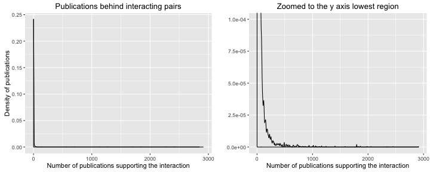

```r
library(dplyr)
tm_full_pair_info <- unique(select(tm_full,pair_id,Nof.Docs,Nof.co.occr.in.Title.Abs,Nof.co.occr.in.Body,tm))

library(ggplot2)

g <- ggplot(data=tm_full_pair_info, aes(tm_full_pair_info$Nof.Docs))
g <- g + geom_density()
g <- g + labs(title ="Publications behind interacting pairs", y = "Density of publications", x= "Number of publications supporting the interaction")

g2 <- g + coord_cartesian(ylim = c(0,0.0001))
g2 <- g2 + labs(title ="Zoomed to the y axis lowest region", x = "Number of publications supporting the interaction", y="")

multiplot(g,g2,cols=2)
```

The graph is not perfect, but it is still informative. I now need to compare the text mining predictions with the IMEx set of interactions.

### Part 2: Comparison with the IMEx dataset

#### Loading the IMEx dataset

I use a small pipeline to put together data from DIP and IntAct. The details can be found [here](https://github.com/pporrasebi/darkspaceproject/IMEx/IMEx_dsgen.md).

```r
imex_full <- read.delim("../../darkspaceproject/IMEx/results//imex_full.txt", header=T, sep="\t",colClasses="character")
```

I select exclusively the human data (interactions where both proteins are human).

```r
imex_human <- unique(subset(imex_full,taxid_a=="9606" & taxid_b=="9606"))
```

#### Comparison between IMEx and the text-mined dataset at the pair level

I compare both datasets using the pair ids.

```r
imex_sel <- unique(select(imex_human,pair_id_clean,pair_id_clean,id_a_clean,id_b_clean,taxid_a,taxid_b,pubid))
imex_sel$imex <- 1
imex_pairs <- unique(select(imex_sel, pair_id=pair_id_clean,imex))

comp <- unique(merge(tm_full_pair_info,imex_pairs,by="pair_id",all=T))

comp <- mutate(comp, db_pair =
                 ifelse(tm == 1 & is.na(imex), "tm",
                 ifelse(is.na(tm) & imex == 1, "imex",
                 ifelse(tm == 1 & imex == 1, "tm & imex",
                 "check"))))

comp$db_pair <- as.factor(comp$db_pair)

comp <- mutate(comp, nr_oc_group =
               ifelse(Nof.Docs <= 5, Nof.Docs, "over 5"))

table(comp$db_pair,useNA="ifany")
```

```
     imex        tm tm & imex
   115667    826434       175
```

```r
comp_simple <- unique(select(comp, pair_id,db_pair))

write.table(comp_simple,"./results/pairs_tm_vs_imex.txt",col.names=T,row.names=F,quote=F,sep="\t")
```

#### Comparison between IMEx and the text-mined dataset at the publication level

Now I will check how many of the publications where the pairs have been reported in the text-mined dataset were curated in IMEx. For that I first need to translate the PMC ids given in the PMCIDs field to PMIDs, in order to be able to compare with the IMEx dataset.

First I obtain the translation table.

```r
if(!file.exists("./source_files/PMID_PMCID_DOI.csv.gz")){
  download.file(url="ftp://ftp.ebi.ac.uk/pub/databases/pmc/DOI/PMID_PMCID_DOI.csv.gz", destfile="./source_files/PMID_PMCID_DOI.csv.gz",method="curl")
}
```

```r
library("data.table")
system("gunzip ./source_files/PMID_PMCID_DOI.csv.gz")

map_pub <- fread("./source_files/PMID_PMCID_DOI.csv",header=T,sep=",",stringsAsFactors=F)
```

[output not shown]

```r
map_pub_sel <- unique(select(map_pub,PMID,PMCID))
```

[output not shown]

```r
rm(map_pub)
system("rm ./source_files/PMID_PMCID_DOI.csv")
```

```r
tm_pmcids <- unique(select(tm_full,PMCIDs))
tm_pmcids2pmids <- merge(tm_pmcids,map_pub_sel,by.x="PMCIDs",by.y="PMCID",all.x=T,all.y=F)
```

[output not shown]

```r
tm_pmcids2pmids <- mutate(tm_pmcids2pmids, PMID =
                 ifelse(is.na(PMID), PMCIDs,
                 PMID))
```

[output not shown]

```r
rm(map_pub_sel)
```

```r
tm_full_map <- unique(merge(tm_full,tm_pmcids2pmids,by="PMCIDs",all.x=T,all.y=F))
```

[output not shown]

```r
tm_sel <- unique(select(tm_full_map,pair_id,pmid=PMCIDs,tm,Nof.Docs,Nof.co.occr.in.Title.Abs,Nof.co.occr.in.Body))
```

[output not shown]

```r
write.table(tm_sel,"./results/pairs_pmids_tm.txt",col.names=T,row.names=F,quote=F,sep="\t")
```

[output not shown]

```r
system("gzip ./results/pairs_pmids_tm.txt")
```

### Part 3: Evaluate occurence of a pair as interaction predictor

Given the limited overlap, I have a quick look to check if the different parameters counted by SK in the EPMC dataset correlate somehow with their presence in the IMEx dataset.

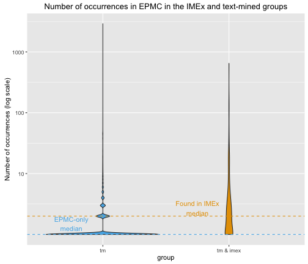

```r
tm_vs_imex <- unique(subset(comp, db_pair == "tm" | db_pair == "tm & imex"))

g3 <- ggplot(data=tm_vs_imex, aes(x=db_pair,y=Nof.Docs))
g3 <- g3 + geom_violin(aes(fill=db_pair))
g3 <- g3 + scale_fill_manual(values=c("#56B4E9","#E69F00"),
                             labels=c("Found in IMEx", "text-mined only"))
g3 <- g3 + scale_y_log10(breaks=c(10,100,1000,10000),
                         labels=function(n){format(n, scientific = FALSE)})
g3 <- g3 + labs(title ="Number of occurrences in EPMC in the IMEx and text-mined groups", y = "Number of occurrences (log scale)", x="group")
g3 <- g3 + geom_hline(yintercept=median(tm_vs_imex[tm_vs_imex$db_pair == "tm",2]), colour="#56B4E9", linetype="dashed")
g3 <- g3 + geom_hline(yintercept=median(tm_vs_imex[tm_vs_imex$db_pair == "tm & imex",2]), colour="#E69F00", linetype="dashed")
g3 <- g3 + annotate("text", x=0.75, median(tm_vs_imex[tm_vs_imex$db_pair == "tm",2])+0.5, label = "EPMC-only\nmedian", colour="#56B4E9")
g3 <- g3 + annotate("text", x=1.75, median(tm_vs_imex[tm_vs_imex$db_pair == "tm & imex",2])+0.7, label = "Found in IMEx\nmedian", colour="#E69F00")
g3 <- g3 + theme(legend.position="none")
g3
```

Now I check the statistical significance of the difference in the number of publications between the set of predicted pairs found in IMEx and the rest.

```r
bartlett.test(tm_vs_imex[,2], tm_vs_imex[,8])
```

```
    Bartlett test of homogeneity of variances

data:  tm_vs_imex[, 2] and tm_vs_imex[, 8]
Bartlett's K-squared = Inf, df = 5, p-value < 2.2e-16
```

```r
nocs_tm <- sample(tm_vs_imex[tm_vs_imex$db_pair == "tm",2], 20000)
nocs_both <- sample(tm_vs_imex[tm_vs_imex$db_pair == "tm & imex",2])

mood.test(nocs_both,nocs_tm,alternative="two.sided")
```

```
    Mood two-sample test of scale

data:  nocs_both and nocs_tm
Z = 12.882, p-value < 2.2e-16
alternative hypothesis: two.sided
```

## Appendix: Keywords describing interaction relationships

- (de)acetylate
- (co)activate
- transactivate
- (dis)associate
- add ?
- bind
- link ?
- catalyse
- cleave
- co(-)immunoprecipitate, co(-)ip
- (de)methylate
- (de)phosphorylate
- (de)phosphorylase
- produce ?
- modify
- impair
- inactivate
- inhibit
- interact
- react
- (dis)assemble
- discharge ?
- modulate
- stimulate
- substitute ?
- (de)ubiquitinate
- heterodimerize
- heterotrimerize
- immunoprecipitate
- (co)assemble
- co-crystal
- complex
- copurifies
- cross-link
- two(-)hybrid, 2(-)hybrid, 2(-)H, yeast two(-) hybrid, yeast 2(-) hybrid), Y(-)2H, classical two(-)hybrid, classical 2(-) hybrid, Gal4 transcription regeneration
- cosediment
- comigrate
- AP(-)MS
- TAP-MS
- Homo (dimer/trimer/tetramer…)
- Oligomerize

## Appendix 2: Extra code

#### Multiplot function

```r
# Multiple plot function
#
# ggplot objects can be passed in ..., or to plotlist (as a list of ggplot objects)
# - cols:   Number of columns in layout
# - layout: A matrix specifying the layout. If present, 'cols' is ignored.
#
# If the layout is something like matrix(c(1,2,3,3), nrow=2, byrow=TRUE),
# then plot 1 will go in the upper left, 2 will go in the upper right, and
# 3 will go all the way across the bottom.
#
multiplot <- function(..., plotlist=NULL, file, cols=1, layout=NULL) {
  library(grid)

  # Make a list from the ... arguments and plotlist
  plots <- c(list(...), plotlist)

  numPlots = length(plots)

  # If layout is NULL, then use 'cols' to determine layout
  if (is.null(layout)) {
    # Make the panel
    # ncol: Number of columns of plots
    # nrow: Number of rows needed, calculated from # of cols
    layout <- matrix(seq(1, cols * ceiling(numPlots/cols)),
                    ncol = cols, nrow = ceiling(numPlots/cols))
  }

 if (numPlots==1) {
    print(plots[[1]])

  } else {
    # Set up the page
    grid.newpage()
    pushViewport(viewport(layout = grid.layout(nrow(layout), ncol(layout))))

    # Make each plot, in the correct location
    for (i in 1:numPlots) {
      # Get the i,j matrix positions of the regions that contain this subplot
      matchidx <- as.data.frame(which(layout == i, arr.ind = TRUE))

      print(plots[[i]], vp = viewport(layout.pos.row = matchidx$row,
                                      layout.pos.col = matchidx$col))
    }
  }
}
```